# Modelling Psychometric Data with Sinh-Arcsinh Distributions

## Model Diagnostics

```r
# Obtain comprehensive diagnostics
summary(model.shash, age = ppvt$age, score = ppvt$raw)
```

```
#> Sinh-Arcsinh Continuous Norming Model
#> -------------------------------------
#> Polynomial degrees:
#>   Location (mu): 3
#>   Scale (sigma): 2
#>   Skewness (epsilon): 1
#>   Tail weight (delta): Fixed at 1
#> Number of observations: 4542
#> Number of parameters: 9
#>
#> Model Fit:
#>   Log-likelihood: -19670.99
#>   AIC: 39359.98
#>   BIC: 39417.77
#>   R-squared: 0.9775
#>   RMSE: 1.5216
#>   Bias: 0.3307
#>
#> Convergence:
#>   Converged: TRUE
#>   Function evaluations: 141
#>   Max gradient: 23945.01
#>   Message: Successful convergence
#>
#> Parameter Estimates:
#> Location (mu) parameters:
#>      Estimate Std..Error z.value  Pr...z..
#> mu_0  187.401     0.5600 334.654 0.000e+00
#> mu_1   26.220     0.6806  38.525 0.000e+00
#> mu_2   -9.830     0.2462 -39.923 0.000e+00
#> mu_3    1.575     0.1937   8.132 4.441e-16
#>
#> Scale (sigma) parameters:
#>              Estimate Std..Error z.value Pr...z..
#> log(sigma)_0  2.78307    0.01854 150.148  0.00000
#> log(sigma)_1 -0.26106    0.01489 -17.530  0.00000
#> log(sigma)_2 -0.02438    0.01110  -2.196  0.02812
#>
#> Skewness (epsilon) parameters:
#>           Estimate Std..Error z.value Pr...z..
#> epsilon_0   0.6796    0.02367   28.71        0
#> epsilon_1   0.2457    0.02277   10.79        0
```

The summary provides:

- Model fit statistics (log-likelihood, AIC, BIC, R²)
- Parameter estimates with standard errors and significance tests
- Convergence diagnostics
- Separate tables for location, scale, and skewness parameters

Key diagnostic indicators:

- **Convergence**: Should be successful (code = 0). If not, please inspect modell visually.
- **R²**: Correlation between fitted and manifest percentiles (> 0.95 desirable)
- **Parameter significance**: Check z-values and p-values for parameter importance

## Custom Model Specifications

For datasets with complex patterns, adjust polynomial degrees and distributional parameters:

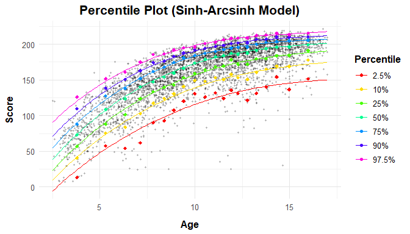

```r
# Example with more complex parameterization (not executed due to computation time)
model.custom <- cnorm.shash(age = ppvt$age, score = ppvt$raw,
                           mu_degree = 3,        # Curvelinear pattern
                           sigma_degree = 3,     # Complex variability changes
                           epsilon_degree = 2,   # Age-varying skewness
                           delta_degree = 2)     # Changing tail weights across age
```

```r
# Compare models
compare(model.shash, model.custom, age = ppvt$age, score = ppvt$raw,
        title = "ShaSh Model Comparison")
```

```
#>
#> Model Comparison Summary:
#> ------------------------
#>  Metric     Model1     Model2 Difference
#>      R2     0.9567     0.9603     0.0037
#>    Bias     0.3129     0.0542    -0.2587
#>    RMSE     2.0976     1.9885    -0.1091
#>     MAD     1.5190     1.4112    -0.1078
#>     AIC 39359.9772 39274.0828   -85.8944
#>     BIC 39417.7673 39363.9785   -53.7888
#>
#> Note: Difference = Model2 - Model1
#>       Fit indices are based on the manifest and fitted norm scores of both models.
#>       Scale metrics are T scores (scaleSD = 10)
#>       AIC and BIC should only be used when comparing models of the same type.
```

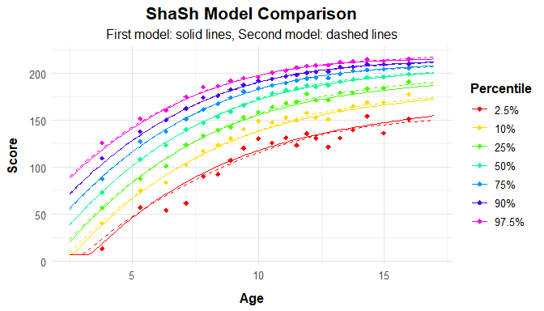

**Note**: Higher polynomial degrees increase model flexibility but may lead to overfitting with insufficient data. Always validate complex models through visual inspection and cross-validation.

## Simplified Alternative

```r
# More conservative parameterization for demonstration
model.simple <- cnorm.shash(age = ppvt$age, score = ppvt$raw,
                           mu_degree = 2,        # Quadratic location pattern
                           sigma_degree = 1,     # Linear variability change
                           epsilon_degree = 1,   # Linear skewness change
                           delta = 1.1)          # Slightly heavy tails
```

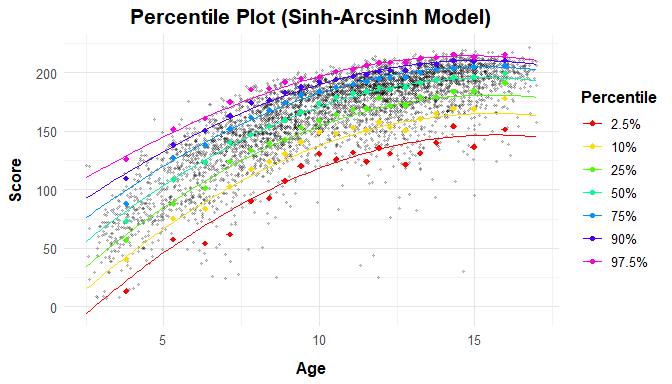

```r
# This model balances flexibility with stability
```

## Post-Stratification and Weighting

ShaSh models support weighted estimation for representative sampling:

```r
# Calculate post-stratification weights
margins <- data.frame(variables = c("sex", "sex", "migration", "migration"),
                     levels = c(1, 2, 0, 1),
                     share = c(.52, .48, .7, .3))

weights <- computeWeights(ppvt, margins)
```

```
#> Raking converged normally after 3 iterations.
```

```r
# Fit weighted ShaSh model
model.weighted <- cnorm.shash(ppvt$age, ppvt$raw, weights = weights)
```

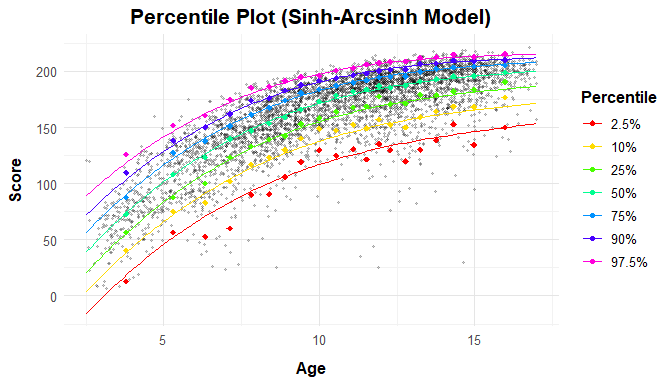

```r
# Compare weighted vs. unweighted
compare(model.shash, model.weighted, age = ppvt$age, score = ppvt$raw,
        title = "Unweighted vs. Weighted ShaSh Models")
```

```
#>
#> Model Comparison Summary:
#> ------------------------
#>  Metric     Model1     Model2 Difference
#>      R2     0.9567     0.9566    -0.0001
#>    Bias     0.3129     0.4622     0.1493
#>    RMSE     2.0976     2.1262     0.0287
#>     MAD     1.5190     1.5541     0.0351
#>     AIC 39359.9772 41352.8375  1992.8603
#>     BIC 39417.7673 41410.6276  1992.8603
#>
#> Note: Difference = Model2 - Model1
#>       Fit indices are based on the manifest and fitted norm scores of both models.
#>       Scale metrics are T scores (scaleSD = 10)
#>       AIC and BIC should only be used when comparing models of the same type.
```

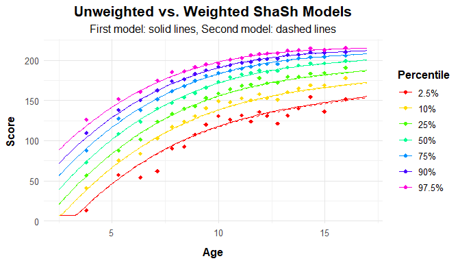

# Norm Score Generation

## Individual Predictions

```r
# Generate norm scores for specific age-score combinations
ages <- c(10.25, 10.75, 11.25, 11.75)
raw_scores <- c(180, 185, 190, 195)

norm_scores <- predict(model.shash, ages, raw_scores)
prediction_table <- data.frame(
  Age = ages,
  Raw_Score = raw_scores,
  Norm_Score = round(norm_scores, 1)
)
print(prediction_table)
```

```
#>     Age Raw_Score Norm_Score
#> 1 10.25       180       53.4
#> 2 10.75       185       54.3
#> 3 11.25       190       55.6
#> 4 11.75       195       57.5
```

## Comprehensive Norm Tables

```r
# Generate detailed norm tables for multiple ages
tables <- normTable.shash(model.shash,
                         ages = c(10.25, 10.75),
                         start = 150,
                         end = 220,
                         step = 1,
                         CI = 0.95,
                         reliability = 0.94)

# Display sample from first table
head(tables[[1]], 10)
```

```
#>      x         Px      Pcum Percentile          z     norm  lowerCI  upperCI
#> 1  150 0.01069892 0.1697324   16.97324 -0.9552233 40.44777 36.36624 45.67556
#> 2  151 0.01112359 0.1788393   17.88393 -0.9197974 40.80203 36.69925 46.00856
#> 3  152 0.01155717 0.1883045   18.83045 -0.8841617 41.15838 37.03422 46.34354
#> 4  153 0.01199968 0.1981352   19.81352 -0.8483008 41.51699 37.37132 46.68063
#> 5  154 0.01245117 0.2083391   20.83391 -0.8121977 41.87802 37.71068 47.02000
#> 6  155 0.01291170 0.2189236   21.89236 -0.7758338 42.24166 38.05251 47.36182
#> 7  156 0.01338142 0.2298963   22.98963 -0.7391884 42.60812 38.39697 47.70629
#> 8  157 0.01386049 0.2412650   24.12650 -0.7022393 42.97761 38.74429 48.05361
#> 9  158 0.01434915 0.2530375   25.30375 -0.6649617 43.35038 39.09470 48.40402
#> 10 159 0.01484770 0.2652220   26.52220 -0.6273283 43.72672 39.44846 48.75777
#>    lowerCI_PR upperCI_PR
#> 1    8.638209   33.27093
#> 2    9.174675   34.48936
#> 3    9.738827   35.73145
#> 4   10.331823   36.99684
#> 5   10.954874   38.28515
#> 6   11.609248   39.59601
#> 7   12.296277   40.92901
#> 8   13.017365   42.28377
#> 9   13.773995   43.65987
#> 10  14.567739   45.05694
```

The norm tables provide:

- **x**: Raw scores
- **Px**: Probability density values
- **Pcum**: Cumulative probabilities
- **Percentile**: Percentile ranks (0-100)
- **z**: Standardized z-scores
- **norm**: Norm scores in specified scale
- **Confidence intervals**: When reliability is specified

# Model Comparison and Selection

## Comparing Distributional Approaches

```r
# Compare ShaSh with other approaches
# Beta-Binomial models should work worse, since the test has stop rules,
# leading to non-binomial distributions. Distribution-free models (Taylor)
# should be able to model the data flexibly as well.
model.bb <- cnorm.betabinomial(ppvt$age, ppvt$raw, n = 228)
```

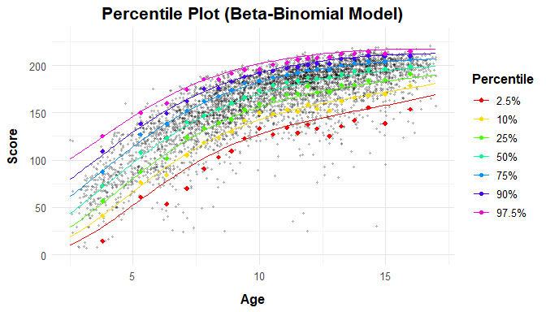

```r
model.taylor <- cnorm(group = ppvt$group, raw = ppvt$raw)
```

```
#> Powers of location: k = 5
#> Powers of age:      t = 3
#> Multiple R2 between raw score and explanatory variable: R2 = 0.6915
#>
#> Final solution: 22 terms (highest consistent model)
#> R-Square Adj. = 0.991584
#> Final regression model: raw ~ L1 + L2 + L3 + L4 + A1 + A2 + A3 + L1A1 + L1A2 + L1A3 + L2A1 + L2A2 + L2A3 + L3A1 + L3A2 + L3A3 + L4A1 + L4A2 + L4A3 + L5A1 + L5A2 + L5A3
#> Regression function: raw ~ 320.4238239 + (-43.52313536*L1) + (1.576062212*L2) + (-0.02330857938*L3) + (0.0001252947997*L4) + (-119.8654247*A1) + (7.700634153*A2) + (-0.1530384974*A3) + (14.50741478*L1A1) + (-0.9423146812*L1A2) + (0.01974974212*L1A3) + (-0.4835093183*L2A1) + (0.03105400924*L2A2) +…
#> Raw Score RMSE = 3.49392
#>
#> Use 'printSubset(model)' to get detailed information on the different solutions, 'plotPercentiles(model) to display percentile plot, plotSubset(model)' to inspect model fit.
```

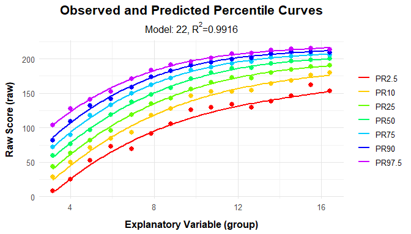

```r
# Visual comparisons
compare(model.shash, model.bb, age = ppvt$age, score = ppvt$raw,
        title = "ShaSh vs. Beta-Binomial")
```

```
#>
#> Model Comparison Summary:
#> ------------------------
#>  Metric     Model1     Model2 Difference
#>      R2     0.9567     0.9368    -0.0198
#>    Bias     0.3129     0.1408    -0.1721
#>    RMSE     2.0976     2.5099     0.4123
#>     MAD     1.5190     1.8816     0.3626
#>     AIC 39359.9772 39856.6454   496.6682
#>     BIC 39417.7673 39908.0144   490.2471
#>
#> Note: Difference = Model2 - Model1
#>       Fit indices are based on the manifest and fitted norm scores of both models.
#>       Scale metrics are T scores (scaleSD = 10)
#>       AIC and BIC should only be used when comparing models of the same type.
```

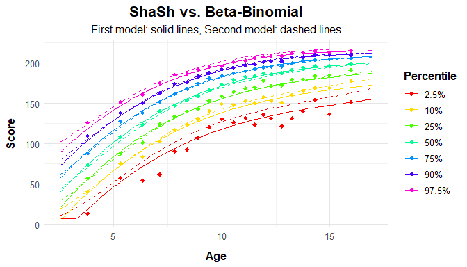

```r
compare(model.taylor, model.shash, age = ppvt$age, score = ppvt$raw,
        title = "Distribution-Free vs. ShaSh")
```

```
#> Retrieving norm scores, please stand by ...
#>
#> Model Comparison Summary:
#> ------------------------
#>  Metric      Model1     Model2 Difference
#>      R2      0.9609     0.9567    -0.0043
#>    Bias      0.0460     0.3129     0.2669
#>    RMSE      1.9787     2.0976     0.1188
#>     MAD      1.4109     1.5190     0.1081
#>     AIC  24320.8609 39359.9772 15039.1163
#>     BIC -21528.1994 39417.7673 60945.9667
#>
#> Note: Difference = Model2 - Model1
#>       Fit indices are based on the manifest and fitted norm scores of both models.
#>       Scale metrics are T scores (scaleSD = 10)
#>       AIC and BIC should only be used when comparing models of the same type.
```

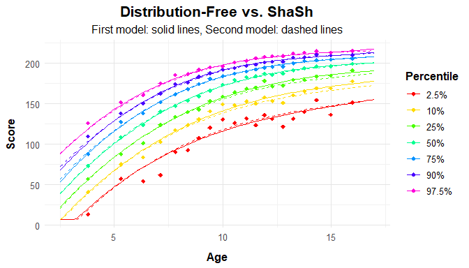

## Decision Framework

The different continuous models have advantages for specific use cases, with the distribution free approach (Taylor polynomials) being the most flexible, the beta-binomial approach being optimal for discrete item counts, and ShaSh being ideal for continuous scores with complex distributional shapes.

Use ShaSh models for

- continuous scores with decimal precision
- complex skewness patterns that change across age
- floor or ceiling effects requiring flexible shape modeling
- zero or negative scores are present

Use Beta-Binomial models for

- discrete item counts from binary scoring
- fixed maximum score (number of test items)
- unspeeded tests with homogeneous item difficulties
- 1PL IRT-based psychometric instruments
- small to moderate number of possible scores

Use distribution-free (Taylor Polynomial) models when

- maximum flexibility is paramount
- no strong distributional assumptions can be made
- quick implementation is needed and manual adjustment is desired

In selecting models, please compare models using:

1. Information criteria: AIC, BIC (lower is better)
2. Fit statistics: R², RMSE, bias
3. Visual inspection: Smoothness, realism of percentile curves
4. Cross-validation: Out-of-sample prediction accuracy
5. Theoretical appropriateness: Match between model assumptions and data characteristics

## Computational Considerations

### Performance Tips

1. **Start simple**: Use default parameters initially, then increase complexity as needed
2. **Monitor convergence**: Check convergence codes and adjust control parameters if necessary
3. **Validate visually**: Always inspect percentile plots for realistic patterns
4. **Use appropriate sample sizes**: Larger samples for higher polynomial degrees
5. **Consider data preprocessing**: Remove extreme outliers that might affect convergence

### Troubleshooting

**Convergence Issues and Numerical Instability:**

- Reduce polynomial degrees
- Adjust delta parameter
- Use simpler control parameters
- Check for data quality issues
- Pay attention to warning messages during optimization

**Overfitting Signs:**

- Wavy, unrealistic percentile curves
- Very high polynomial degrees relative to sample size
- Poor out-of-sample prediction

# Conclusion

The Sinh-Arcsinh distribution provides a sophisticated yet practical framework for modeling psychometric norm data. Its ability to independently control location, scale, skewness, and tail weight makes it particularly valuable for applications where traditional parametric approaches are inadequate due to distributional complexity.

**Best practices for ShaSh modeling:**

1. Carefully assess data characteristics before model selection
2. Use appropriate sample sizes for model complexity
3. Validate models through visually and via statistical indicators (R2, AIC, Bias)
4. Compare alternative distributional assumptions. Is distribution-free or beta-binomial more appropriate?
5. Document model selection rationale

# References

Jones, M. C., & Pewsey, A. (2009). Sinh-arcsinh distributions. *Biometrika*, 96(4), 761-780.

Lenhard, A., Lenhard, W., Gary, S. (2019). Continuous norming of psychometric tests: A simulation study of parametric and semi-parametric approaches. *PLoS ONE*, 14(9), e0222279. https://doi.org/10.1371/journal.pone.0222279

Lenhard, W., Lenhard, A., & Gary, S. (2025). cNORM: Continuous norming. R package version 3.5.0. https://CRAN.R-project.org/package=cNORM